# ECO 395M exercise 2

Minjin Kang, Paul Park

2023-02-18

## 1) Saratoga house prices

We used `SaratogaHouses` data to build the optimal pricing model. We first separated `SaratogaHouses` data into a training and a testing set, then used the testing set to assess the model’s out-of-sample performance.

For our best linear model, we added some interaction variables like `livingArea:lotSize` `livingArea:fuel` `livingArea:centralAir` `bedrooms:bathrooms` `heating:fuel`. We compared the RMSEs of the “medium” model and our model to evaluate the performance.

| Medium_model_rmse |
| --- |
| 69294.845 |
| Model_made_by_us_rmse |
| 70006.466 |

```
## [1] 2
```

To build the best KNN regression model, we first found the optimal K, **2**, that produces the lowest RMSE value. This value was used in the “horse race” between the two model classes.

| RMSE_KNN | RMSE_LM |
| --- | --- |
| 73938.29 | 64547.93 |
| 72919.69 | 63192.76 |
| 79690.28 | 68079.75 |
| 68477.91 | 57096.02 |
| 74223.05 | 70076.84 |
| 77286.25 | 67833.07 |

|  | x |
| --- | --- |
| Mean KNN RMSE | 72623.51 |
| Mean LM RMSE | 65167.31 |

For the comparison, we ran 150 random train/test splits. First table shows the first six results, which shows that the RMSE of our model beats that of the KNN model overall.

Looking at the second table, we can observe that our linear model has the lower **average** out-of-sample RMSE compared to that of the KNN model.

## 2) Classification and retrospective sampling

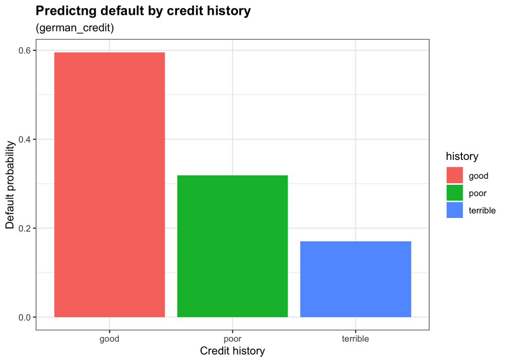

**Figure 1:** Bar plot showing average default probability by credit history.

|  | coefficient |
| --- | --- |
| (Intercept) | -0.73 |
| duration | 0.03 |
| amount | 0.00 |
| installment | 0.21 |
| age | -0.02 |
| historypoor | -1.14 |
| historyterrible | -1.91 |
| purposeedu | 0.66 |
| purposegoods/repair | 0.05 |
| purposenewcar | 0.73 |
| purposeusedcar | -1.06 |
| foreigngerman | -1.07 |

| history | count |
| --- | --- |
| good | 89 |
| poor | 618 |
| terrible | 293 |

The bar plot shows that a borrower with a ‘good’ credit rating history has the highest probability of defaulting on a loan, followed by ‘poor,’ and ‘terrible.’ Similar result is again found in the logistic regression model, which shows that ‘historyterrible’ and ‘historybad’ are more negatively correlated with ‘Default,’ than the intercept (historygood). Both results indicate that a borrower with a good credit history is more likely to default on his/her loan, which is **highly counter-intuitive,** which made us suspect something was not right.

This data set is not appropriate for predicting “high” vs. “low” probably of default when screening prospective borrowers. Sampling defaulted loans and matching similar kinds of loans will inevitably lead to a biased prediction because the majority of samples collected are borrowers with poor and terrible credit rating as shown in the table above. Rather, the bank should use a random selection (and/or a much larger sample size) when collecting samples to better predict the probability of defaults.

## 3) Children and hotel reservations

### Model building

Here, we will build a predictive model for whether a hotel booking will have children on it. We start by splitting train/test data with `hotels_dev.csv`, and making baseline 1 and baseline 2 models as instructed.

For the best linear model, we added what we considered to be meaningful interactions, such as `adults:stays_in_weekend_nights`, `adults:total_of_special_requests`, `adults:average_daily_rate`, and `average_daily_rate:total_of_special_request`.

Below are the predictions on the testing set, which we will use this to measure out-of-sample performance.

|  | 0 |
| --- | --- |
| 0 | 8242 |
| 1 | 758 |

| Accuracy(%) |
| --- |
| 91.58 |

**Table set 1:** Left is a Confusion matrix for baseline 1 model that used only four features. On its right is the out-of-sample accuracy.

Looking at above confusion matrix, one may ask why is there a missing column? That is because the baseline 1 model never predicted children.

|  | 0 | 1 |
| --- | --- | --- |
| 0 | 8122 | 120 |
| 1 | 483 | 275 |

| Accuracy(%) |
| --- |
| 93.3 |

**Table set 2:** Left table is Confusion matrix for baseline 2 model that used all possible predictors except for arrival_date. On its right is the out-of-sample accuracy.

One can see that baseline 2 model performs better than base line 1 model.

|  | 0 | 1 |
| --- | --- | --- |
| 0 | 8127 | 115 |
| 1 | 491 | 267 |

| Accuracy(%) |
| --- |
| 93.27 |

**Table set 3:** Left table is Confusion matrix for the best linear model we made with additional interaction variables. On its right is the out-of-sample accuracy.

### Model validation : STEP 1

Here, we validate our best model by testing it on an entirely fresh data, `hotels_val.csv`

| ROC_FPR | ROC_TPR |
| --- | --- |
| 0.7098107 | 0.9726368 |
| 0.6562976 | 0.9626866 |
| 0.5897324 | 0.9502488 |
| 0.5194692 | 0.9427861 |
| 0.4524690 | 0.9278607 |
| 0.3911246 | 0.9029851 |

To produce an ROC curve plot, we first made a dataframe consisting of False Positive Rate values and True Positive Rate values for each threshold t. Above are the first six results using head(df) command.

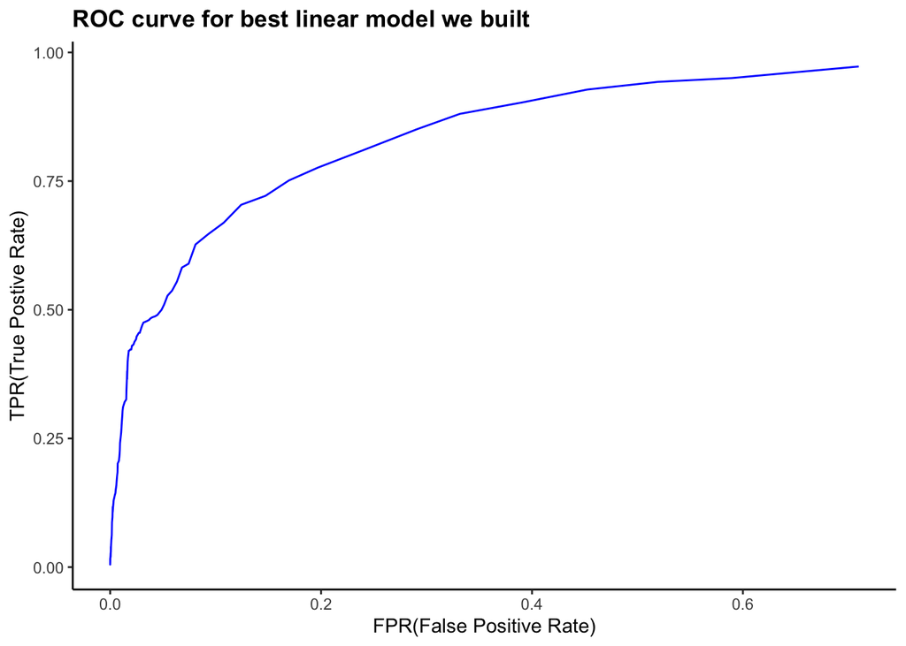

**Plot 2:** ROC curve (FPR(t) vs TPR(t)) for our best model, using new dataset `hotels_val.csv`

While working through the problem, we came across a cool package called `ROCR`. Just for the kicks, we tried generating the ROC curve again using this package, which generated a similar curve as above.

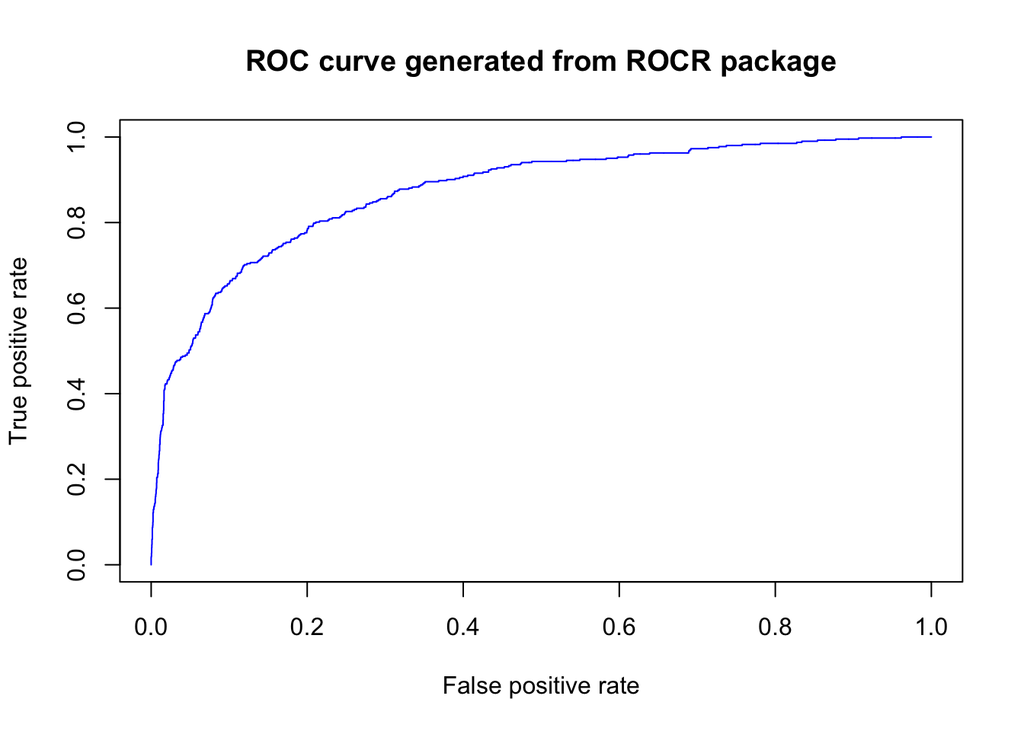

**Plot 2:** ROC curve (using `ROCR` packcage) showing True Positive Rate against the False Positive Rate for different threshold t. This took less time and fewer lines of codes. Simple and fast!

### Model validation : STEP 2

Let’s create 20 folds of `hotels_val.csv`. For each fold set, we have 250 bookings showing expected number of children and actual number of children.

| fold | expected_child | actual_child |
| --- | --- | --- |
| 1 | 19.62884 | 22 |
| 2 | 19.64119 | 16 |
| 3 | 20.13133 | 25 |
| 4 | 14.98581 | 11 |
| 5 | 22.86121 | 24 |
| 6 | 19.84653 | 22 |
| 7 | 18.07072 | 17 |
| 8 | 22.38424 | 19 |
| 9 | 19.66975 | 23 |
| 10 | 19.33569 | 20 |
| 11 | 24.91357 | 29 |
| 12 | 23.51683 | 18 |
| 13 | 20.17733 | 17 |
| 14 | 17.49258 | 16 |
| 15 | 19.21680 | 19 |
| 16 | 18.76782 | 18 |
| 17 | 18.36647 | 19 |
| 18 | 22.26414 | 24 |
| 19 | 21.14476 | 24 |
| 20 | 19.58440 | 19 |

**Table 4:** 20 folds each with expected number of children (left) and actual number of children (right) for comparison.

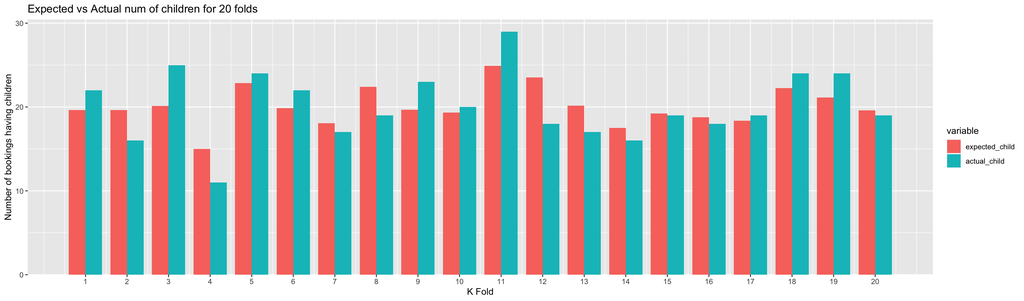

**Plot 3:** Grouped bar plot showing 20 fold sets comparing expected number of children and actual number of children (Red=expected, Green=actual).

As one can clearly see from **Table 4** and **Plot 3**, our model does a pretty accurate job at predicting the total number of bookings with children in a group of 250 bookings overall.